# Parker_MACHINE_LEARNING_PROJECT

Parker

February 8, 2018

## Background

Using devices such as Jawbone Up, Nike FuelBand, and Fitbit it is now possible to collect a large amount of data about personal activity relatively inexpensively. These type of devices are part of the quantified self movement - a group of enthusiasts who take measurements about themselves regularly to improve their health, to find patterns in their behavior, or because they are tech geeks. One thing that people regularly do is quantify how much of a particular activity they do, but they rarely quantify how well they do it. In this project, your goal will be to use data from accelerometers on the belt, forearm, arm, and dumbell of 6 participants. They were asked to perform barbell lifts correctly and incorrectly in 5 different ways. More information is available from the website here: http://web.archive.org/web/20161224072740/http:/groupware.les.inf.puc-rio.br/har (see the section on the Weight Lifting Exercise Dataset).

### Packages and final dataset prepared

```r
#library list
suppressWarnings(library(gbm))
suppressWarnings(library(caret))
```

```r
suppressWarnings(library(ggplot2))
suppressWarnings(library(lattice))
suppressWarnings(library(rpart))
suppressWarnings(library(rpart.plot))
suppressWarnings(library(rattle))
suppressWarnings(library(randomForest))
# read raw data
setwd("C:/Users/hyh/Desktop/Coursera/R/machines learning/final project for week 4")
testing <- read.csv("pml-testing.csv")
training  <- read.csv("pml-training.csv")

classindex <- createDataPartition(training$classe, p=.7, list = FALSE)
Training_Train<-training[classindex,]
Training_Test<-training[-classindex,]
dim(Training_Test)
```

```
## [1] 5885  160
```

```r
#summary of data and remove variables with near zero variance and NA values
str(Training_Train)
```

```
## 'data.frame':    13737 obs. of  160 variables:
##  $ X                       : int  3 4 5 7 9 11 12 13 15 16 ...
##  $ user_name               : Factor w/ 6 levels "adelmo","carlitos",..: 2 2 2 2 2 2 2 2 2 2 ...
##  $ raw_timestamp_part_1    : int  1323084231 1323084232 1323084232 1323084232 1323084232 1323084232 1323084232 1323084232 1323084232 1323084232 ...
##  $ raw_timestamp_part_2    : int  820366 120339 196328 368296 484323 500302 528316 560359 604281 644302 ...
##  $ cvtd_timestamp          : Factor w/ 20 levels "02/12/2011 13:32",..: 9 9 9 9 9 9 9 9 9 9 ...
##  $ new_window              : Factor w/ 2 levels "no","yes": 1 1 1 1 1 1 1 1 1 1 ...
##  $ num_window              : int  11 12 12 12 12 12 12 12 12 12 ...
##  $ roll_belt               : num  1.42 1.48 1.48 1.42 1.43 1.45 1.43 1.42 1.45 1.48 ...
##  $ pitch_belt              : num  8.07 8.05 8.07 8.09 8.16 8.18 8.18 8.2 8.2 8.15 ...
##  $ yaw_belt                : num  -94.4 -94.4 -94.4 -94.4 -94.4 -94.4 -94.4 -94.4 -94.4 -94.4 ...
##  $ total_accel_belt        : int  3 3 3 3 3 3 3 3 3 3 ...
##  $ kurtosis_roll_belt      : Factor w/ 397 levels "","-0.016850",..: 1 1 1 1 1 1 1 1 1 1 ...
##  $ kurtosis_picth_belt     : Factor w/ 317 levels "","-0.021887",..: 1 1 1 1 1 1 1 1 1 1 ...
##  $ kurtosis_yaw_belt       : Factor w/ 2 levels "","#DIV/0!": 1 1 1 1 1 1 1 1 1 1 ...
```

[output cut: 86 more lines]

```r
dim(Training_Train)
```

```
## [1] 13737   160
```

```r
dim(Training_Test)
```

```
## [1] 5885  160
```

```r
Training_Train_1<-Training_Train[, -nearZeroVar(Training_Train)]
Training_Test_1<-Training_Test[, -nearZeroVar(Training_Train)]
str(Training_Test_1)
```

```
## 'data.frame':    5885 obs. of  104 variables:
##  $ X                       : int  1 2 6 8 10 14 20 24 27 37 ...
##  $ user_name               : Factor w/ 6 levels "adelmo","carlitos",..: 2 2 2 2 2 2 2 2 2 2 ...
##  $ raw_timestamp_part_1    : int  1323084231 1323084231 1323084232 1323084232 1323084232 1323084232 1323084232 1323084232 1323084233 1323084233 ...
##  $ raw_timestamp_part_2    : int  788290 808298 304277 440390 484434 576390 788335 996313 72305 448310 ...
##  $ cvtd_timestamp          : Factor w/ 20 levels "02/12/2011 13:32",..: 9 9 9 9 9 9 9 9 9 9 ...
##  $ num_window              : int  11 11 12 12 12 12 12 12 13 13 ...
##  $ roll_belt               : num  1.41 1.41 1.45 1.42 1.45 1.42 1.59 1.51 1.54 1.41 ...
##  $ pitch_belt              : num  8.07 8.07 8.06 8.13 8.17 8.21 8.07 8.1 8.11 8.11 ...
##  $ yaw_belt                : num  -94.4 -94.4 -94.4 -94.4 -94.4 -94.4 -94.4 -94.4 -94.4 -94.3 ...
##  $ total_accel_belt        : int  3 3 3 3 3 3 3 3 3 3 ...
##  $ max_roll_belt           : num  NA NA NA NA NA NA NA -94.3 NA NA ...
##  $ max_picth_belt          : int  NA NA NA NA NA NA NA 3 NA NA ...
##  $ min_roll_belt           : num  NA NA NA NA NA NA NA -94.4 NA NA ...
##  $ min_pitch_belt          : int  NA NA NA NA NA NA NA 3 NA NA ...
```

[output cut: 86 more lines]

```r
dim(Training_Test_1)
```

```
## [1] 5885  104
```

```r
dim(Training_Train_1)
```

```
## [1] 13737   104
```

```r
NAS <- sapply(Training_Train_1, function(x) mean(is.na(x))) > 0.50
Training_Train_2 <- Training_Train_1[, NAS!=TRUE]
Training_Test_2  <- Training_Test_1[, NAS!=TRUE]
dim(Training_Test_2)
```

```
## [1] 5885   59
```

```r
dim(Training_Train_2)
```

```
## [1] 13737    59
```

```r
#Final dataset created

Train_Final <- subset(Training_Train_2, select=-c(1, user_name, raw_timestamp_part_1, raw_timestamp_part_2, cvtd_timestamp))
Test_Final  <- subset(Training_Test_2, select=-c(1, user_name, raw_timestamp_part_1, raw_timestamp_part_2, cvtd_timestamp))
dim(Train_Final)
```

```
## [1] 13737    54
```

## Modelling Analysis including Random Forest, Decision Tree and Boosting

```r
#correlation coef
cor(Train_Final[-54])
```

[output not shown]

[output cut: 863 more lines]

```
## magnet_dumbbell_y       -0.0428973266
## magnet_dumbbell_z       -0.5819196347
## roll_forearm             0.4104290903
## pitch_forearm           -0.0108617240
## yaw_forearm              0.0602237349
## total_accel_forearm     -0.0099516663
## gyros_forearm_x          0.1844968535
## gyros_forearm_y          0.0577502407
## gyros_forearm_z         -0.0008254706
## accel_forearm_x          0.0658450446
## accel_forearm_y          0.2883826030
## accel_forearm_z         -0.5450771091
## magnet_forearm_x        -0.1310544780
## magnet_forearm_y         0.2443280506
## magnet_forearm_z         1.0000000000
```

[figure not shown]

```r
#Decistion Tree

set.seed(23456)
model_Fit_DT <- train(classe ~ ., data=Train_Final, method="rpart")
fancyRpartPlot(model_Fit_DT$finalModel)
```

```r
predict_DT<- predict(model_Fit_DT, Test_Final)
confusionMatrix(predict_DT, Test_Final$classe)
```

```
## Confusion Matrix and Statistics
##
##           Reference
## Prediction    A    B    C    D    E
##          A 1507  443  483  413  103
##          B   28  406   34  168   79
##          C  133  290  509  349  244
##          D    0    0    0    0    0
##          E    6    0    0   34  656
##
## Overall Statistics
##
##                Accuracy : 0.523
##                  95% CI : (0.5102, 0.5359)
##     No Information Rate : 0.2845
##     P-Value [Acc > NIR] : < 2.2e-16
##
##                   Kappa : 0.3781
##  Mcnemar's Test P-Value : < 2.2e-16
##
## Statistics by Class:
##
##                      Class: A Class: B Class: C Class: D Class: E
## Sensitivity            0.9002  0.35645  0.49610   0.0000   0.6063
## Specificity            0.6576  0.93489  0.79090   1.0000   0.9917
## Pos Pred Value         0.5110  0.56783  0.33377      NaN   0.9425
## Neg Pred Value         0.9431  0.85822  0.88142   0.8362   0.9179
## Prevalence             0.2845  0.19354  0.17434   0.1638   0.1839
## Detection Rate         0.2561  0.06899  0.08649   0.0000   0.1115
## Detection Prevalence   0.5011  0.12150  0.25913   0.0000   0.1183
## Balanced Accuracy      0.7789  0.64567  0.64350   0.5000   0.7990
```

```r
#Accuray for decisiont tree
confusionMatrix(predict_DT, Test_Final$classe)$overall[[1]]
```

```
## [1] 0.5230246
```

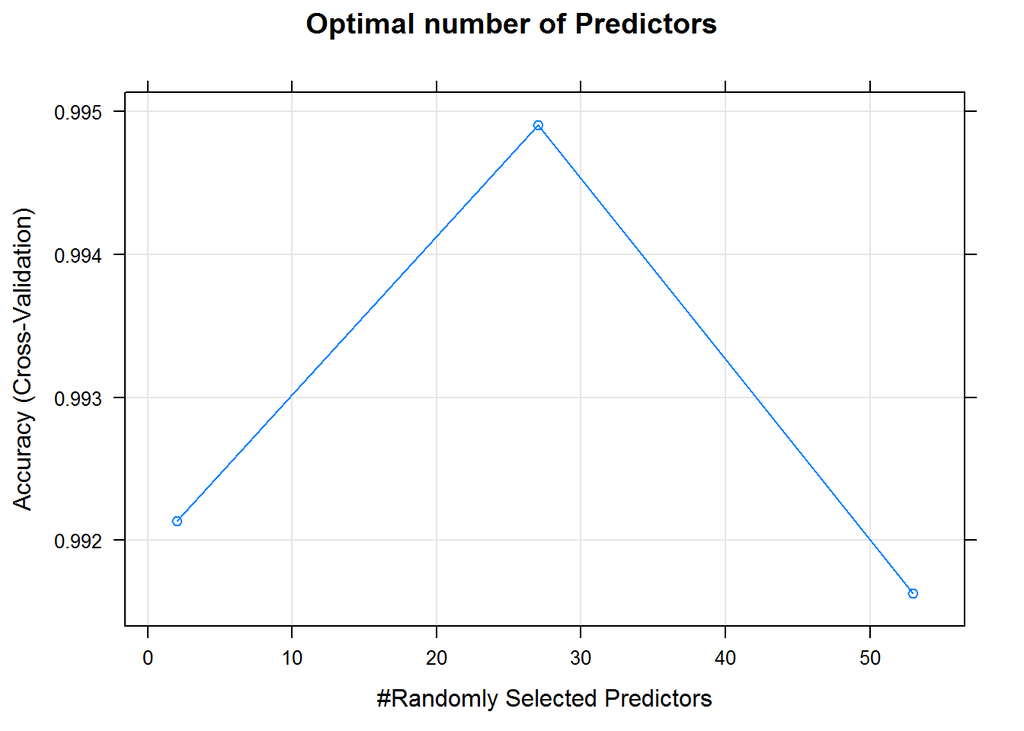

```r
# Random Forest
set.seed(23456)
model_RF <- train(classe ~ ., data=Train_Final, method="rf",
                          trControl=trainControl(method="cv", number=3, verboseIter=FALSE))
plot(model_RF, main = "Optimal number of Predictors")
```

```r
model_RF$finalModel
```

```
##
## Call:
##  randomForest(x = x, y = y, mtry = param$mtry)
##                Type of random forest: classification
##                      Number of trees: 500
## No. of variables tried at each split: 27
##
##         OOB estimate of  error rate: 0.22%
## Confusion matrix:
##      A    B    C    D    E  class.error
## A 3904    1    0    0    1 0.0005120328
## B    4 2650    4    0    0 0.0030097818
## C    0    4 2390    2    0 0.0025041736
## D    0    0    9 2242    1 0.0044404973
## E    0    1    0    3 2521 0.0015841584
```

```r
# The final value used for the model was mtry = 27.

predict_RF<- predict(model_RF, Test_Final)
confusionMatrix(predict_RF, Test_Final$classe)
```

```
## Confusion Matrix and Statistics
##
##           Reference
## Prediction    A    B    C    D    E
##          A 1674    1    0    0    0
##          B    0 1137    4    0    0
##          C    0    1 1022   10    0
##          D    0    0    0  954    0
##          E    0    0    0    0 1082
##
## Overall Statistics
##
##                Accuracy : 0.9973
##                  95% CI : (0.9956, 0.9984)
##     No Information Rate : 0.2845
##     P-Value [Acc > NIR] : < 2.2e-16
##
##                   Kappa : 0.9966
##  Mcnemar's Test P-Value : NA
##
## Statistics by Class:
##
##                      Class: A Class: B Class: C Class: D Class: E
## Sensitivity            1.0000   0.9982   0.9961   0.9896   1.0000
## Specificity            0.9998   0.9992   0.9977   1.0000   1.0000
## Pos Pred Value         0.9994   0.9965   0.9894   1.0000   1.0000
## Neg Pred Value         1.0000   0.9996   0.9992   0.9980   1.0000
## Prevalence             0.2845   0.1935   0.1743   0.1638   0.1839
## Detection Rate         0.2845   0.1932   0.1737   0.1621   0.1839
## Detection Prevalence   0.2846   0.1939   0.1755   0.1621   0.1839
## Balanced Accuracy      0.9999   0.9987   0.9969   0.9948   1.0000
```

```r
#Accuray for random Forest
confusionMatrix(predict_RF, Test_Final$classe)$overall[[1]]
```

```
## [1] 0.9972812
```

```r
varImp(model_RF)
```

```
## rf variable importance
##
##   only 20 most important variables shown (out of 53)
##
##                      Overall
## num_window           100.000
## roll_belt             64.892
## pitch_forearm         38.924
## yaw_belt              31.239
## magnet_dumbbell_z     30.061
## magnet_dumbbell_y     29.464
## pitch_belt            28.240
## roll_forearm          23.895
## accel_dumbbell_y      12.802
## roll_dumbbell         11.451
## accel_forearm_x       11.374
## magnet_dumbbell_x     10.288
## accel_belt_z           8.843
## accel_dumbbell_z       8.549
## total_accel_dumbbell   8.442
## magnet_belt_y          7.213
## magnet_belt_z          7.169
## magnet_forearm_z       6.930
## magnet_belt_x          5.977
## roll_arm               5.857
```

```r
#Generalized Boosted Model

set.seed(23456)
controlGBM <- trainControl(method = "repeatedcv", number = 4, repeats = 2)
model_GBM  <- train(classe ~ ., data=Train_Final, method = "gbm",
                    trControl = controlGBM, verbose = FALSE)
model_GBM$finalModel
```

```
## A gradient boosted model with multinomial loss function.
## 150 iterations were performed.
## There were 53 predictors of which 41 had non-zero influence.
```

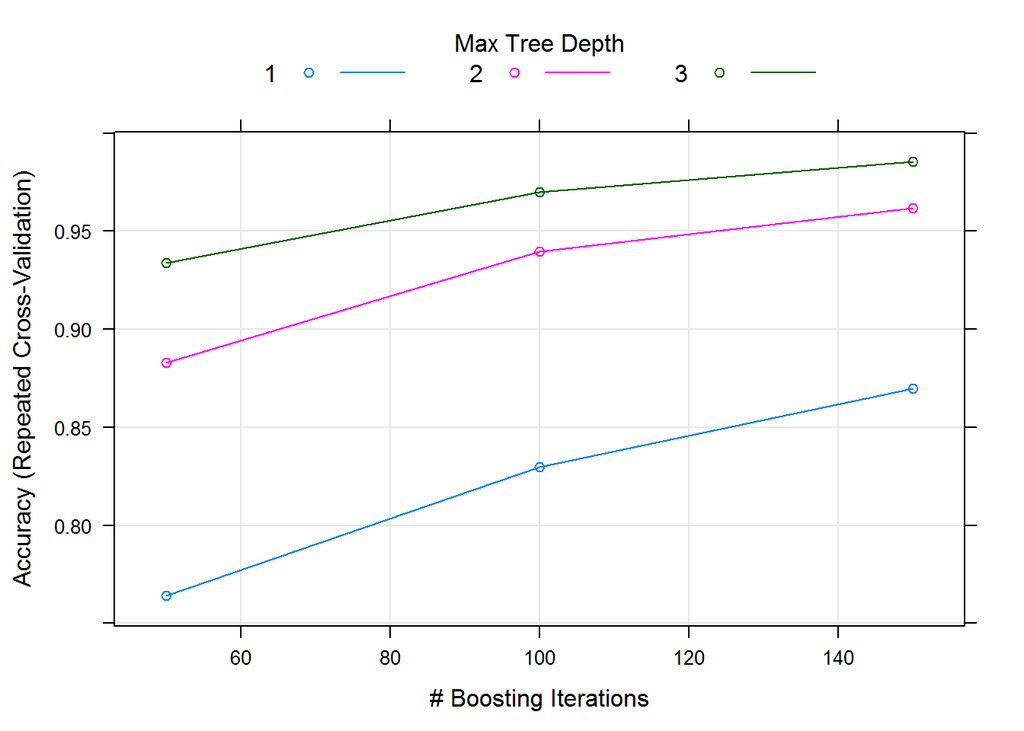

```r
plot(model_GBM)
```

```r
predict_GBM<- predict(model_GBM, Test_Final)
confusionMatrix(predict_GBM, Test_Final$classe)
```

```
## Confusion Matrix and Statistics
##
##           Reference
## Prediction    A    B    C    D    E
##          A 1672    4    0    1    2
##          B    1 1119   16    0    2
##          C    0   15 1006   18    1
##          D    1    1    1  942   10
##          E    0    0    3    3 1067
##
## Overall Statistics
##
##                Accuracy : 0.9866
##                  95% CI : (0.9833, 0.9894)
##     No Information Rate : 0.2845
##     P-Value [Acc > NIR] : < 2.2e-16
##
##                   Kappa : 0.983
##  Mcnemar's Test P-Value : NA
##
## Statistics by Class:
##
##                      Class: A Class: B Class: C Class: D Class: E
## Sensitivity            0.9988   0.9824   0.9805   0.9772   0.9861
## Specificity            0.9983   0.9960   0.9930   0.9974   0.9988
## Pos Pred Value         0.9958   0.9833   0.9673   0.9864   0.9944
## Neg Pred Value         0.9995   0.9958   0.9959   0.9955   0.9969
## Prevalence             0.2845   0.1935   0.1743   0.1638   0.1839
## Detection Rate         0.2841   0.1901   0.1709   0.1601   0.1813
## Detection Prevalence   0.2853   0.1934   0.1767   0.1623   0.1823
## Balanced Accuracy      0.9986   0.9892   0.9868   0.9873   0.9924
```

```r
#Accuray for GBM
confusionMatrix(predict_GBM, Test_Final$classe)$overall[[1]]
```

```
## [1] 0.986576
```

### In conclusion, it could be seen clearly that Random Forest would become better model to predict clasess among the training data by comparing accuray for these three model including decision tree, random forest and boosting. Moreover, the optimal number of variables by using random forest is 27

## Appling Random Forest to the test data for quiz

```r
predictTEST <- predict(model_RF, testing[,-(1:5)])
predictTEST
```

```
##  [1] B A B A A E D B A A B C B A E E A B B B
## Levels: A B C D E
```